# Chronological and gestational DNAm age estimation using different methylation-based clocks

Dolors Pelegri and Juan R Gonzalez

Institute for Global Health (ISGlobal), Barcelona, Spain Bioinformatics Research Group in Epidemiolgy (BRGE) http://brge.isglobal.org

2022-07-11

#### Package

methylclock 0.8.0.1

# 1 Description of implemented clocks

This manual describes how to estimate chronological and gestational DNA methylation (DNAm) age as well as biological age using different methylation clocks. The package includes the following estimators:

## 1.2 Gestational DNAm age (in weeks)

- **Knight’s clock**: It uses 148 CpGs described in Knight et al. (2016). It was trained using 27K and 450K arrays in cord blood samples.
- **Bohlin’s clock**: It uses 96 CpGs described in Bohlin et al. (2016). It was trained using 450K array in cord blood samples.
- **Mayne’s clock**: It uses 62 CpGs described in Mayne et al. (2017). It was trained using 27K and 450K.
- **EPIC clock**: EPIC-based predictor of gestational age. It uses 176 CpGs described in Haftorn et al. (2021). It was trained using EPIC arrays in cord blood samples.
- **Lee’s clocks**: Three different biological clocks described in Lee et al. (2019) are implemented. It was trained for 450K and EPIC arrays in placenta samples.
  - **RPC clock**: Robust placental clock (RPC). It uses 558 CpG sites.
  - **CPC clock**: Control placental clock (CPC). It usses 546 CpG sites.
  - **Refined RPC clock**: Useful for uncomplicated term pregnancies (e.g. gestational age >36 weeks). It uses 396 CpG sites.

The biological DNAm clocks implemented in our package are:

- **Levine’s clock** (also know as PhenoAge): It uses 513 CpGs described in Levine et al. (2018). It was trained using 27K, 450K and EPIC arrays in blood samples.
- **Telomere Length’s clock** (TL): It uses 140 CpGs described in Lu et al. (2019) It was trained using 450K and EPIC arrays in blood samples.

The main aim of this package is to facilitate the interconnection with R and Bioconductor’s infrastructure and, hence, avoiding submitting data to online calculators. Additionally, `methylclock` also provides an unified way of computing DNAm age to help downstream analyses.

# 2 Getting started

The package depends on some R packages that can be previously installed into your computer by:

```r
library(BiocManager)
install(c("tidyverse", "impute", "Rcpp"))
```

Then `methylclock` package is installed into your computer by executing:

```r
library(devtools)
install_github("isglobal-brge/methylclock")
```

The package is loaded into R as usual:

```r
library(methylclock)
```

These libraries are required to reproduce this document:

```r
library(Biobase)
library(tibble)
library(impute)
library(ggplot2)
library(ggpmisc)
library(GEOquery)
```

# 3 DNA Methylation clocks

The main function to estimate chronological and biological mDNA age is called `DNAmAge` while the gestational DNAm age is estimated using `DNAmGA` function. Both functions have similar input arguments. Next subsections detail some of the important issues to be consider before computing DNAm clocks.

## 3.1 Data format

The methylation data is given in the argument `x`. They can be either beta or M values. The argument `toBetas` should be set to TRUE when M values are provided. The `x` object can be:

- A **matrix** with CpGs in rows and individuals in columns having the name of the CpGs in the rownames.
- A **data frame** or a **tibble** with CpGs in rows and individuals in columns having the name of the CpGs in the first column (e.g. cg00000292, cg00002426, cg00003994, …) as required in the Horvath’s DNA Methylation Age Calculator website (https://dnamage.genetics.ucla.edu/home).
- A **GenomicRatioSet** object, the default method to encapsulate methylation data in `minfi` Bioconductor package.
- An **ExpressionSet** object as obtained, for instance, when downloading methylation data from GEO (https://www.ncbi.nlm.nih.gov/geo/).

## 3.2 Data nomalization

In principle, data can be normalized by using any of the existing standard methods such as QN, ASMN, PBC, SWAN, SQN, BMIQ (see a revision of those methods in Wang et al. (2015)). `DNAmAge` function includes the BMIQ method proposed by Teschendorff et al. (2012) using Horvath’s robust implementation that basically consists of an optimal R code implementation and optimization procedures. This normalization is recommended by Horvath since it improves the predictions for his clock. This normalization procedure is very time-consuming. In order to overcome these difficulties, we have parallelize this process using `BiocParallel` library. This step is not mandatory, so that, you can use your normalized data and set the argument `normalize` equal to FALSE (default).

## 3.3 Missing individual’s data

All the implemented methods require complete cases. `DNAmAge` function has an imputation method based on KNN implemented in the function `knn.impute` from `impute` Bioconductor package. This is performed when missing data is present in the CpGs used in any of the computed clocks. There is also another option based on a fast imputation method that imputes missing values by the median of required CpGs as recommended in Bohlin et al. (2016). This is recommended when analyzing 450K arrays since `knn.impute` for large datasets may be very time consuming. Fast imputation can be performed by setting `fastImp=TRUE` which is not the default value.

## 3.4 Missing CpGs of DNAm clocks

By default the package computes the different clocks when there are more than 80% of the required CpGs of each method. Nothing is required when having missing CpGs since the main functions will return NA for those estimators when this criteria is not meet. Let us use a test dataset (`TestDataset`) which is available within the package to illustrate the type of information we are obtaining:

```r
cpgs.missing <- checkClocks(TestDataset)
```

```
  There are some clocks that cannot be computed since your data do not contain the required CpGs.
          These are the total number of missing CpGs for each clock :

          clock Cpgs_in_clock missing_CpGs percentage
  1     Horvath           353            2        0.6
  2      Hannum            71           64       90.1
  3      Levine           513            3        0.6
  4 SkinHorvath           391          283       72.4
  5       PedBE            94           91       96.8
  6          Wu           111            2        1.8
  7          TL           140          137       97.9
  8        BLUP        319607       300288       94.0
  9          EN           514          476       92.6
```

```r
cpgs.missing.GA <- checkClocksGA(TestDataset)
```

```
  There are some clocks that cannot be computed since your data do not contain the required CpGs.
          These are the total number of missing CpGs for each clock :

     clock Cpgs_in_clock missing_CpGs percentage
  1 Knight           148            0        0.0
  2 Bohlin            96           87       90.6
  3  Mayne            62            0        0.0
  4    Lee          1125         1072       95.3
  5   EPIC           176          170       96.6
```

The objects `cpgs.missing` and `cpgs.missing.GA` are lists having the missing CpGs of each clock

```r
names(cpgs.missing)
```

```
  [1] "Horvath"     "Hannum"      "Levine"      "skinHorvath" "PedBE"
  [6] "Wu"          "TL"          "BLUP"        "EN"
```

We can see which are those CpGs for a given clock (for example Hannum) just typing:

```r
cpgs.missing$Hannum
```

```
   [1] "cg20822990"      "cg22512670"      "cg25410668"      "cg04400972"
   [5] "cg16054275"      "cg10501210"      "ch.2.30415474F"  "cg22158769"
   [9] "cg02085953"      "cg06639320"      "cg22454769"      "cg24079702"
  [13] "cg23606718"      "cg22016779"      "cg03607117"      "cg07553761"
  [17] "cg00481951"      "cg25478614"      "cg25428494"      "cg02650266"
  [21] "cg08234504"      "cg23500537"      "cg20052760"      "cg16867657"
  [25] "cg06685111"      "cg00486113"      "cg13001142"      "cg20426994"
  [29] "cg14361627"      "cg08097417"      "cg07955995"      "cg22285878"
  [33] "cg03473532"      "cg08540945"      "cg07927379"      "cg16419235"
  [37] "cg07583137"      "cg22796704"      "cg19935065"      "cg23091758"
  [41] "cg23744638"      "cg04940570"      "cg11067179"      "cg22213242"
  [45] "cg06419846"      "cg02046143"      "cg00748589"      "cg18473521"
  [49] "cg01528542"      "ch.13.39564907R" "cg03032497"      "cg04875128"
  [53] "cg09651136"      "cg03399905"      "cg04416734"      "cg07082267"
  [57] "cg14692377"      "cg06874016"      "cg21139312"      "cg02867102"
  [61] "cg19283806"      "cg14556683"      "cg07547549"      "cg08415592"
```

In Section 4.1 we describe how to change this 80% threshold.

## 3.5 Cell counts

The EEAA method requires to estimate cell counts. We use the package `meffil` (Min et al. (2018)) that provides some functions to estimate cell counts using predefined datasets. This is performed by setting `cell.count=TRUE` (default value). The reference panel is passed through the argument `cell.count.reference`. So far, the following options are available:

- **“blood gse35069 complete”**: methylation profiles from Reinius et al. (2012) for purified blood cell types. It includes CD4T, CD8T, Mono, Bcell, NK, Neu and Eos.
- **“blood gse35069”**: methylation profiles from Reinius et al. (2012) for purified blood cell types. It includes CD4T, CD8T, Mono, Bcell, NK and Gran.
- **“blood gse35069 chen”**: methylation profiles from Chen et al. (2017) blood cell types. It includes CD4T, CD8T, Mono, Bcell, NK, Neu and Eos.
- **“andrews and bakulski cord blood”**. Cord blood reference from Bakulski et al. (2016). It includes Bcell, CD4T, CD8T, Gran, Mono, NK and nRBC.
- **“cord blood gse68456”** Cord blood methylation profiles from Goede et al. (2015). It includes CD4T, CD8T, Mono, Bcell, NK, Neu, Eos and RBC.
- **“gervin and lyle cord blood”** Cord blood reference generated by Kristina Gervin and Robert Lyle, available at `miffil` package. It includes CD14, Bcell, CD4T, CD8T, NK, Gran.
- **“saliva gse48472”**: Reference generated from the multi-tissue pannel from Slieker et al. (2013). It includes Buccal, CD4T, CD8T, Mono, Bcell, NK, Gran.
- **“guintivano dlpfc”**: Reference generated from Guintivano, Aryee, and Kaminsky (2013). It includes dorsolateral prefrontal cortex, NeuN_neg and NeuN_pos.
- **“combined cord blood”**: References generated based in samples assayed by Bakulski et al, Gervin et al., de Goede et al., and Lin et al. It includes umbilical cord blood, Bcell, CD4T, CD8T, Gran, Mono, NK and nRBC
- **“placenta”**: References from Yuan et al. (2021), Yuan (2022). It includes placental cells from third trimester Trophoblasts, Stromal, Hofbauer, Endothelial, nRBC, Syncytiotrophoblast.

# 4 Chronological and biological DNAm age estimation

Next we illustrate how to estimate the chronological DNAm age using several datasets which aim to cover different data input formats.

**IMPORTANT NOTE**: On some systems we can find an error in the `DNAmAge()` function when parameter `cell.count = TRUE`. This error is related to `preprocessCore` package and can be fixed by disabling multi-threading when installing the preprocessCore package using the command

```
BiocManager::install("preprocessCore",
                     configure.args = "--disable-threading",
                     force = TRUE)
```

## 4.1 Data in Horvath’s format (e.g. `csv` with CpGs in rows)

Let us start by reproducing the results proposed in Horvath (2013). It uses the format available in the file ’MethylationDataExample55.csv” from his tutorial (available [here](https://dnamage.genetics.ucla.edu/home)). These data are available at `methylclock` package. Although these data can be loaded into R by using standard functions such as `read.csv` we hihgly recommend to use functions from `tidiverse`, in particular `read_csv` from `readr` package. The main reason is that currently researchers are analyzing Illumina 450K or EPIC arrays that contains a huge number of CpGs that can take a long time to be loaded when using basic importing R function. These functions import `csv` data as tibble which is one of the possible formats of `DNAmAge` function

```r
library(tidyverse)
path <- system.file("extdata", package = "methylclock")
MethylationData <- read_csv(file.path(path, "MethylationDataExample55.csv"))
MethylationData
```

```
  # A tibble: 27,578 x 17
     ProbeID GSM946048 GSM946049 GSM946052 GSM946054 GSM946055 GSM946056 GSM946059
     <chr>       <dbl>     <dbl>     <dbl>     <dbl>     <dbl>     <dbl>     <dbl>
   1 cg0000~    0.706    0.730     0.705     0.751     0.715     0.634     0.682
   2 cg0000~    0.272    0.274     0.311     0.279     0.178     0.269     0.330
   3 cg0000~    0.0370   0.0147    0.0171    0.0290    0.0163    0.0243    0.0127
   4 cg0000~    0.133    0.120     0.121     0.107     0.110     0.129     0.102
   5 cg0000~    0.0309   0.0192    0.0217    0.0132    0.0181    0.0243    0.0199
   6 cg0000~    0.0700   0.0715    0.0655    0.0719    0.0914    0.0508    0.0294
   7 cg0000~    0.993    0.993     0.993     0.994     0.991     0.994     0.993
   8 cg0000~    0.0215   0.0202    0.0187    0.0169    0.0162    0.0143    0.0172
   9 cg0000~    0.0105   0.00518   0.00410   0.00671   0.00758   0.00518   0.00543
  10 cg0001~    0.634    0.635     0.621     0.639     0.599     0.591     0.594
  # ... with 27,568 more rows, and 9 more variables: GSM946062 <dbl>,
  #   GSM946064 <dbl>, GSM946065 <dbl>, GSM946066 <dbl>, GSM946067 <dbl>,
  #   GSM946073 <dbl>, GSM946074 <dbl>, GSM946075 <dbl>, GSM946076 <dbl>
```

*IMPORTANT NOTE*: Be sure that the first column contains the CpG names. Sometimes, your imported data look like this one (it can happen, for instance, if the `csv` file was created in R without indicating `row.names=FALSE`)

```
> mydata

# A tibble: 473,999 x 6
      X1 Row.names BIB_15586_1X BIB_33043_1X EDP_5245_1X KAN_584_1X
   <int> <chr>            <dbl>        <dbl>       <dbl>      <dbl>
 1     1 cg000000~       0.635        0.575       0.614      0.631
 2     2 cg000001~       0.954        0.948       0.933      0.950
 3     3 cg000001~       0.889        0.899       0.901      0.892
 4     4 cg000001~       0.115        0.124       0.107      0.123
 5     5 cg000002~       0.850        0.753       0.806      0.815
 6     6 cg000002~       0.676        0.771       0.729      0.665
 7     7 cg000002~       0.871        0.850       0.852      0.863
 8     8 cg000003~       0.238        0.174       0.316      0.206
```

If so, the first column must be removed before being used as the input object in `DNAmAge` funcion. It can be done using `dplyr` function

```
> mydata2 <- select(mydata, -1)

# A tibble: 473,999 x 5
      Row.names BIB_15586_1X BIB_33043_1X EDP_5245_1X KAN_584_1X
    <chr>            <dbl>        <dbl>       <dbl>      <dbl>
 1    cg000000~       0.635        0.575       0.614      0.631
 2    cg000001~       0.954        0.948       0.933      0.950
 3    cg000001~       0.889        0.899       0.901      0.892
 4    cg000001~       0.115        0.124       0.107      0.123
 5    cg000002~       0.850        0.753       0.806      0.815
 6    cg000002~       0.676        0.771       0.729      0.665
 7    cg000002~       0.871        0.850       0.852      0.863
 8    cg000003~       0.238        0.174       0.316      0.206
```

In any case, if you use the object `mydata` that contains the CpGs in the second column, you will see this error message:

```
> DNAmAge(mydata)
Error in DNAmAge(mydata) : First column should contain CpG names
```

Once data is in the proper format, DNAmAge can be estimated by simply:

```r
age.example55 <- DNAmAge(MethylationData)
age.example55
```

```
  # A tibble: 16 x 11
     id      Horvath Hannum Levine   BNN skinHorvath PedBE    Wu TL    BLUP  EN
     <chr>     <dbl> <lgl>   <dbl> <dbl> <lgl>       <lgl> <dbl> <lgl> <lgl> <lgl>
   1 GSM946~   51.8  NA      -30.3 56.4  NA          NA    1.08  NA    NA    NA
   2 GSM946~   39.8  NA      -29.6 42.1  NA          NA    0.808 NA    NA    NA
   3 GSM946~   26.4  NA      -33.3 25.6  NA          NA    0.772 NA    NA    NA
   4 GSM946~   34.0  NA      -36.0 28.0  NA          NA    0.941 NA    NA    NA
   5 GSM946~   10.1  NA      -52.8 13.4  NA          NA    0.456 NA    NA    NA
   6 GSM946~   20.4  NA      -42.2 16.7  NA          NA    0.621 NA    NA    NA
   7 GSM946~    6.00 NA      -44.8  7.54 NA          NA    0.258 NA    NA    NA
   8 GSM946~   34.6  NA      -23.2 34.6  NA          NA    0.624 NA    NA    NA
   9 GSM946~    7.91 NA      -49.8 12.0  NA          NA    0.237 NA    NA    NA
  10 GSM946~    4.72 NA      -48.2  6.43 NA          NA    0.396 NA    NA    NA
  11 GSM946~   29.6  NA      -39.9 28.5  NA          NA    0.413 NA    NA    NA
  12 GSM946~    1.38 NA      -48.3  3.48 NA          NA    0.122 NA    NA    NA
  13 GSM946~   56.0  NA      -26.7 47.3  NA          NA    0.714 NA    NA    NA
  14 GSM946~   24.0  NA      -39.7 23.3  NA          NA    0.676 NA    NA    NA
  15 GSM946~    9.38 NA      -45.4 11.9  NA          NA    0.251 NA    NA    NA
  16 GSM946~   38.8  NA      -27.5 41.4  NA          NA    0.599 NA    NA    NA
```

As mention in Section 3.4 some clocks returns NA when there are more than 80% of the required CpGs are missing as we can see when typing

```r
missCpGs <- checkClocks(MethylationData)
```

```
  There are some clocks that cannot be computed since your data do not contain the required CpGs.
          These are the total number of missing CpGs for each clock :

          clock Cpgs_in_clock missing_CpGs percentage
  1     Horvath           353            0        0.0
  2      Hannum            71           64       90.1
  3      Levine           513            0        0.0
  4 SkinHorvath           391          282       72.1
  5       PedBE            94           91       96.8
  6          Wu           111            0        0.0
  7          TL           140          137       97.9
  8        BLUP        319607       300192       93.9
  9          EN           514          476       92.6
```

Here we can observe that 72.1% of the required CpGs for SkinHorvath clock are missing. We could estimate DNAm age using this clock just changing the argument `min.perc` in `DNAmAge`. For example, we can indicate that the minimum amount of required CpGs for computing a given clock should be 25%.

```r
age.example55.2 <- DNAmAge(MethylationData, min.perc = 0.25)
age.example55.2
```

```
  # A tibble: 16 x 11
     id      Horvath Hannum Levine   BNN skinHorvath PedBE    Wu TL    BLUP  EN
     <chr>     <dbl> <lgl>   <dbl> <dbl>       <dbl> <lgl> <dbl> <lgl> <lgl> <lgl>
   1 GSM946~   51.8  NA      -30.3 56.4         7.15 NA    1.08  NA    NA    NA
   2 GSM946~   39.8  NA      -29.6 42.1         7.09 NA    0.808 NA    NA    NA
   3 GSM946~   26.4  NA      -33.3 25.6         5.93 NA    0.772 NA    NA    NA
   4 GSM946~   34.0  NA      -36.0 28.0         6.34 NA    0.941 NA    NA    NA
   5 GSM946~   10.1  NA      -52.8 13.4         5.76 NA    0.456 NA    NA    NA
   6 GSM946~   20.4  NA      -42.2 16.7         5.79 NA    0.621 NA    NA    NA
   7 GSM946~    6.00 NA      -44.8  7.54        5.64 NA    0.258 NA    NA    NA
   8 GSM946~   34.6  NA      -23.2 34.6         5.55 NA    0.624 NA    NA    NA
   9 GSM946~    7.91 NA      -49.8 12.0         5.06 NA    0.237 NA    NA    NA
  10 GSM946~    4.72 NA      -48.2  6.43        5.48 NA    0.396 NA    NA    NA
  11 GSM946~   29.6  NA      -39.9 28.5         6.19 NA    0.413 NA    NA    NA
  12 GSM946~    1.38 NA      -48.3  3.48        4.91 NA    0.122 NA    NA    NA
  13 GSM946~   56.0  NA      -26.7 47.3         7.07 NA    0.714 NA    NA    NA
  14 GSM946~   24.0  NA      -39.7 23.3         6.23 NA    0.676 NA    NA    NA
  15 GSM946~    9.38 NA      -45.4 11.9         5.57 NA    0.251 NA    NA    NA
  16 GSM946~   38.8  NA      -27.5 41.4         6.69 NA    0.599 NA    NA    NA
```

In that case, we see as SkinHorvath clock is estimated (though it can be observed that the estimation is not very accurate - this is why we considered at least having 80% of the required CpGs).

By default all available clocks (Horvath, Hannum, Levine, BNN, skinHorvath, …) are estimated. One may select a set of clocks by using the argument `clocks` as follows:

```r
age.example55.sel <- DNAmAge(MethylationData,
                             clocks=c("Horvath", "BNN"))
age.example55.sel
```

```
  # A tibble: 16 x 3
     id        Horvath   BNN
     <chr>       <dbl> <dbl>
   1 GSM946048   51.8  56.4
   2 GSM946049   39.8  42.1
   3 GSM946052   26.4  25.6
   4 GSM946054   34.0  28.0
   5 GSM946055   10.1  13.4
   6 GSM946056   20.4  16.7
   7 GSM946059    6.00  7.54
   8 GSM946062   34.6  34.6
   9 GSM946064    7.91 12.0
  10 GSM946065    4.72  6.43
  11 GSM946066   29.6  28.5
  12 GSM946067    1.38  3.48
  13 GSM946073   56.0  47.3
  14 GSM946074   24.0  23.3
  15 GSM946075    9.38 11.9
  16 GSM946076   38.8  41.4
```

## 4.2 Age acceleration

However, in epidemiological studies one is interested in assessing whether age acceleration is associated with a given trait or condition. Three different measures can be computed:

- **ageAcc**: Difference between DNAmAge and chronological age.
- **ageAcc2**: Residuals obtained after regressing chronological age and DNAmAge (similar to IEAA).
- **ageAcc3**: Residuals obtained after regressing chronological age and DNAmAge adjusted for cell counts (similar to EEAA).

All this estimates can be obtained for each clock when providing chronological age through `age` argument. This information is normally provided in a different file including different covariates (metadata or sample annotation data). In this example data are available at ‘SampleAnnotationExample55.csv’ file that is also available at `methylclock` package:

```r
covariates <- read_csv(file.path(path,
                                 "SampleAnnotationExample55.csv"))
covariates
```

```
  # A tibble: 16 x 14
     OriginalOrder id      title geo_accession TissueDetailed Tissue diseaseStatus
             <dbl> <chr>   <chr> <chr>         <chr>          <chr>          <dbl>
   1             3 GSM946~ Auti~ GSM946048     Fresh frozen ~ occip~             1
   2             4 GSM946~ Cont~ GSM946049     Fresh frozen ~ occip~             0
   3             7 GSM946~ Auti~ GSM946052     Fresh frozen ~ occip~             1
   4             9 GSM946~ Auti~ GSM946054     Fresh frozen ~ occip~             1
   5            10 GSM946~ Auti~ GSM946055     Fresh frozen ~ occip~             1
   6            11 GSM946~ Auti~ GSM946056     Fresh frozen ~ occip~             1
   7            14 GSM946~ Cont~ GSM946059     Fresh frozen ~ occip~             0
   8            17 GSM946~ Cont~ GSM946062     Fresh frozen ~ occip~             0
   9            19 GSM946~ Auti~ GSM946064     Fresh frozen ~ occip~             1
  10            20 GSM946~ Auti~ GSM946065     Fresh frozen ~ occip~             1
  11            21 GSM946~ Auti~ GSM946066     Fresh frozen ~ occip~             1
  12            22 GSM946~ Cont~ GSM946067     Fresh frozen ~ occip~             0
  13            28 GSM946~ Cont~ GSM946073     Fresh frozen ~ occip~             0
  14            29 GSM946~ Cont~ GSM946074     Fresh frozen ~ occip~             0
  15            30 GSM946~ Cont~ GSM946075     Fresh frozen ~ occip~             0
  16            31 GSM946~ Cont~ GSM946076     Fresh frozen ~ occip~             0
  # ... with 7 more variables: Age <dbl>, PostMortemInterval <dbl>,
  #   CauseofDeath <chr>, individual <dbl>, Female <dbl>, Caucasian <lgl>,
  #   FemaleOriginal <lgl>
```

In this case, chronological age is available at `Age` column:

```r
age <- covariates$Age
head(age)
```

```
  [1] 60 39 28 39  8 22
```

The different methylation clocks along with their age accelerated estimates can be simply computed by:

```r
age.example55 <- DNAmAge(MethylationData, age=age,
                         cell.count=TRUE)
age.example55
```

```
  # A tibble: 16 x 24
     id       Horvath ageAcc.Horvath ageAcc2.Horvath ageAcc3.Horvath Hannum Levine
     <chr>      <dbl>          <dbl>           <dbl>           <dbl> <lgl>   <dbl>
   1 GSM9460~   51.8          -8.22          -4.45            -4.91  NA      -30.3
   2 GSM9460~   39.8           0.754          2.00             1.59  NA      -29.6
   3 GSM9460~   26.4          -1.59          -1.67            -1.86  NA      -33.3
   4 GSM9460~   34.0          -5.00          -3.76            -0.463 NA      -36.0
   5 GSM9460~   10.1           2.06          -0.428            2.82  NA      -52.8
   6 GSM9460~   20.4          -1.61          -2.42            -2.88  NA      -42.2
   7 GSM9460~    6.00          2.00          -0.971           -0.827 NA      -44.8
   8 GSM9460~   34.6           6.65           6.57             5.32  NA      -23.2
   9 GSM9460~    7.91          2.91           0.0589          -2.61  NA      -49.8
  10 GSM9460~    4.72          2.72          -0.489            1.46  NA      -48.2
  11 GSM9460~   29.6          -0.427         -0.268           -1.37  NA      -39.9
  12 GSM9460~    1.38          0.375         -2.95            -2.19  NA      -48.3
  13 GSM9460~   56.0          -4.01          -0.242            1.62  NA      -26.7
  14 GSM9460~   24.0           2.03           1.23            -0.669 NA      -39.7
  15 GSM9460~    9.38          1.38          -1.11            -0.885 NA      -45.4
  16 GSM9460~   38.8           8.76           8.92             5.85  NA      -27.5
  # ... with 17 more variables: ageAcc.Levine <dbl>, ageAcc2.Levine <dbl>,
  #   ageAcc3.Levine <dbl>, BNN <dbl>, ageAcc.BNN <dbl>, ageAcc2.BNN <dbl>,
  #   ageAcc3.BNN <dbl>, skinHorvath <lgl>, PedBE <lgl>, Wu <dbl>,
  #   ageAcc.Wu <dbl>, ageAcc2.Wu <dbl>, ageAcc3.Wu <dbl>, TL <lgl>, BLUP <lgl>,
  #   EN <lgl>, age <dbl>
```

By default, the argument `cell.count` is set equal to TRUE and, hence, can be omitted. This implies that `ageAcc3` will be computed for all clocks. In some occassions this can be very time consuming. In such cases one can simply estimate DNAmAge, accAge and accAge2 by setting `cell.count=FALSE`. NOTE: see section 3.5 to see the reference panels available to estimate cell counts.

Then, we can investigate, for instance, whether the accelerated age is associated with Autism. In that example we will use a non-parametric test (NOTE: use t-test or linear regression for large sample sizes)

```r
autism <- covariates$diseaseStatus
kruskal.test(age.example55$ageAcc.Horvath ~ autism)
```

```
    Kruskal-Wallis rank sum test

  data:  age.example55$ageAcc.Horvath by autism
  Kruskal-Wallis chi-squared = 1.3346, df = 1, p-value = 0.248
```

```r
kruskal.test(age.example55$ageAcc2.Horvath ~ autism)
```

```
    Kruskal-Wallis rank sum test

  data:  age.example55$ageAcc2.Horvath by autism
  Kruskal-Wallis chi-squared = 3.1875, df = 1, p-value = 0.0742
```

```r
kruskal.test(age.example55$ageAcc3.Horvath ~ autism)
```

```
    Kruskal-Wallis rank sum test

  data:  age.example55$ageAcc3.Horvath by autism
  Kruskal-Wallis chi-squared = 2.8235, df = 1, p-value = 0.09289
```

## 4.3 Chronological age prediction using `ExpressionSet` data

One may be interested in assessing association between chronologial age and DNA methylation age or evaluating how well chronological age is predicted by DNAmAge. In order to illustrate this analysis we downloaded data from GEO corresponding to a set of healthy individuals (GEO accession number GSE58045). Data can be retrieved into R by using `GEOquery` package as an `ExpressionSet` object that can be the input of our main function.

```r
dd <- GEOquery::getGEO("GSE58045")
gse58045 <- dd[[1]]
```

```r
gse58045
```

```
  ExpressionSet (storageMode: lockedEnvironment)
  assayData: 27578 features, 172 samples
    element names: exprs
  protocolData: none
  phenoData
    sampleNames: GSM1399890 GSM1399891 ... GSM1400061 (172 total)
    varLabels: title geo_accession ... twin:ch1 (43 total)
    varMetadata: labelDescription
  featureData
    featureNames: cg00000292 cg00002426 ... cg27665659 (27578 total)
    fvarLabels: ID Name ... ORF (38 total)
    fvarMetadata: Column Description labelDescription
  experimentData: use 'experimentData(object)'
    pubMedIds: 22532803
  Annotation: GPL8490
```

The chronological age is obtained by using `pData` function from `Biobase` package that is able to deal with `ExpressionSet` objects:

```r
pheno <- pData(gse58045)
age <- as.numeric(pheno$`age:ch1`)
```

And the different DNA methylation age estimates are obtained by using `DNAmAge` function (NOTE: as there are missing values, the program automatically runs `impute.knn` function to get complete cases):

```r
age.gse58045 <- DNAmAge(gse58045, age=age)
```

```
  Imputing missing data of the entire matrix ....
  Data imputed. Starting DNAm clock estimation ...
```

```r
age.gse58045
```

```
  # A tibble: 172 x 24
     id       Horvath ageAcc.Horvath ageAcc2.Horvath ageAcc3.Horvath Hannum Levine
     <chr>      <dbl>          <dbl>           <dbl>           <dbl> <lgl>   <dbl>
   1 GSM1399~    65.6          1.07            4.58            5.46  NA       50.7
   2 GSM1399~    66.3          0.197           4.06            5.06  NA       51.3
   3 GSM1399~    53.9         -5.31           -2.98           -2.42  NA       40.5
   4 GSM1399~    40.6         -5.23           -5.89           -6.14  NA       31.3
   5 GSM1399~    50.1          0.982           1.06            1.28  NA       41.1
   6 GSM1399~    63.7         -0.895           2.64            2.92  NA       48.1
   7 GSM1399~    44.7         -0.875          -1.59           -1.76  NA       29.2
   8 GSM1399~    59.7         -8.55           -4.20           -3.48  NA       41.0
   9 GSM1399~    48.4         -5.84           -4.63           -2.50  NA       43.8
  10 GSM1399~    59.3         -3.93           -0.719          -0.609 NA       46.1
  # ... with 162 more rows, and 17 more variables: ageAcc.Levine <dbl>,
  #   ageAcc2.Levine <dbl>, ageAcc3.Levine <dbl>, BNN <dbl>, ageAcc.BNN <dbl>,
  #   ageAcc2.BNN <dbl>, ageAcc3.BNN <dbl>, skinHorvath <lgl>, PedBE <lgl>,
  #   Wu <dbl>, ageAcc.Wu <dbl>, ageAcc2.Wu <dbl>, ageAcc3.Wu <dbl>, TL <lgl>,
  #   BLUP <lgl>, EN <lgl>, age <dbl>
```

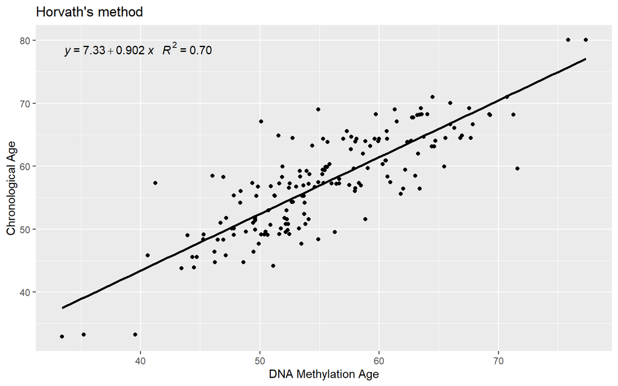

```r
plotDNAmAge(age.gse58045$Horvath, age)
```

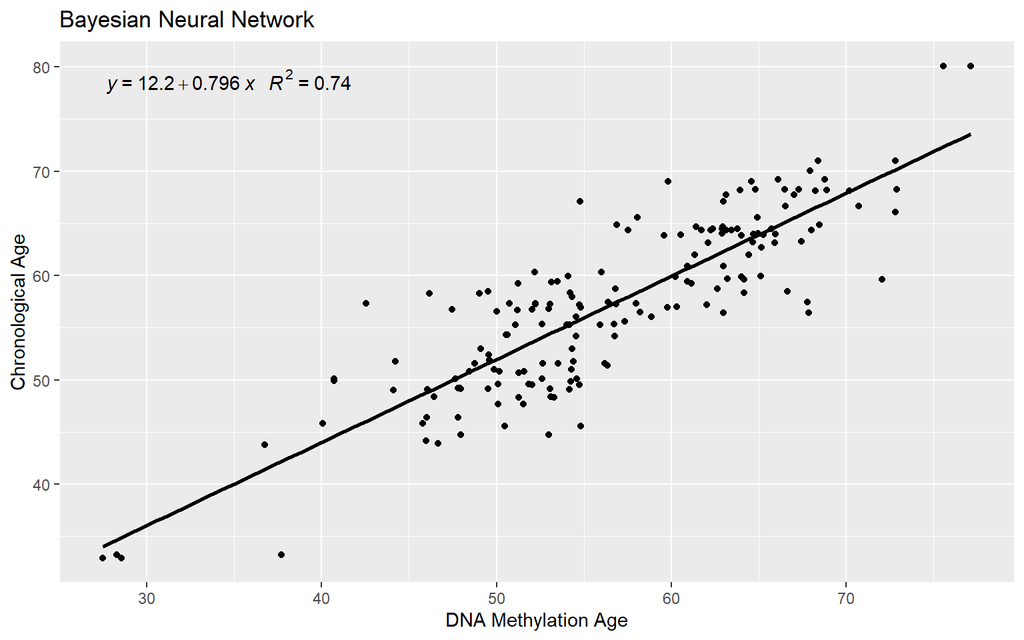

```r
plotDNAmAge(age.gse58045$BNN, age, tit="Bayesian Neural Network")
```

## 4.4 Use of DNAmAge in association studies

Let us illustrate how to use DNAmAge information in association studies (e.g case/control, smokers/non-smokers, responders/non-responders, …). GEO number GSE19711 contains transcriptomic and epigenomic data of a study in lung cancer. Data can be retrieved into R by

```r
dd <- GEOquery::getGEO("GSE19711")
gse19711 <- dd[[1]]
```

The object `gse19711`is an `ExpressionSet` that can contains CpGs and phenotypic (e.g clinical) information

```r
gse19711
```

```
  ExpressionSet (storageMode: lockedEnvironment)
  assayData: 27578 features, 540 samples
    element names: exprs
  protocolData: none
  phenoData
    sampleNames: GSM491937 GSM491938 ... GSM492476 (540 total)
    varLabels: title geo_accession ... stage:ch1 (58 total)
    varMetadata: labelDescription
  featureData
    featureNames: cg00000292 cg00002426 ... cg27665659 (27578 total)
    fvarLabels: ID Name ... ORF (38 total)
    fvarMetadata: Column Description labelDescription
  experimentData: use 'experimentData(object)'
    pubMedIds: 20219944
  Annotation: GPL8490
```

Let us imagine we are interested in comparing the accelerated age between cases and controls. Age and case/control status information can be obtained by:

```r
pheno <- pData(gse19711)
age <- as.numeric(pheno$`ageatrecruitment:ch1`)
disease <- pheno$`sample type:ch1`
table(disease)
```

```
  disease
     bi-sulphite converted genomic whole blood DNA from Case
                                                         266
  bi-sulphite converted genomic whole blood DNA from Control
                                                         274
```

```r
disease[grep("Control", disease)] <- "Control"
disease[grep("Case", disease)] <- "Case"
disease <- factor(disease, levels=c("Control", "Case"))
table(disease)
```

```
  disease
  Control    Case
      274     266
```

The DNAmAge estimates of different methods is computed by

```r
age.gse19711 <- DNAmAge(gse19711, age=age)
```

```
  Imputing missing data of the entire matrix ....
  Data imputed. Starting DNAm clock estimation ...
```

We can observe there are missing data. The funcion automatically impute those using `impute.knn` function from `impute` package since complete cases are required to compute the different methylation clocks. The estimates are:

```r
age.gse19711
```

```
  # A tibble: 540 x 24
     id       Horvath ageAcc.Horvath ageAcc2.Horvath ageAcc3.Horvath Hannum Levine
     <chr>      <dbl>          <dbl>           <dbl>           <dbl> <lgl>   <dbl>
   1 GSM4919~    62.9          -5.14          -0.351          -1.10  NA       61.1
   2 GSM4919~    68.8         -12.2           -2.85           -2.13  NA       57.0
   3 GSM4919~    60.0           3.96           4.54            4.37  NA       43.0
   4 GSM4919~    57.9          -4.13          -1.45           -1.38  NA       40.9
   5 GSM4919~    59.0         -13.0           -6.79           -6.98  NA       57.0
   6 GSM4919~    57.0          -4.00          -1.66           -1.09  NA       44.7
   7 GSM4919~    61.9          -3.08           0.657           0.183 NA       47.9
   8 GSM4919~    59.1         -11.9           -6.07           -5.53  NA       50.0
   9 GSM4919~    60.7         -16.3           -8.33           -9.33  NA       47.7
  10 GSM4919~    51.1          -7.93          -6.30           -6.33  NA       52.5
  # ... with 530 more rows, and 17 more variables: ageAcc.Levine <dbl>,
  #   ageAcc2.Levine <dbl>, ageAcc3.Levine <dbl>, BNN <dbl>, ageAcc.BNN <dbl>,
  #   ageAcc2.BNN <dbl>, ageAcc3.BNN <dbl>, skinHorvath <lgl>, PedBE <lgl>,
  #   Wu <dbl>, ageAcc.Wu <dbl>, ageAcc2.Wu <dbl>, ageAcc3.Wu <dbl>, TL <lgl>,
  #   BLUP <lgl>, EN <lgl>, age <dbl>
```

The association between disease status and DNAmAge estimated using Horvath’s method can be computed by

```r
mod.horvath1 <- glm(disease ~ ageAcc.Horvath ,
                   data=age.gse19711,
                   family="binomial")
summary(mod.horvath1)
```

```
  Call:
  glm(formula = disease ~ ageAcc.Horvath, family = "binomial",
      data = age.gse19711)

  Deviance Residuals:
     Min      1Q  Median      3Q     Max
  -1.358  -1.160  -1.030   1.184   1.771

  Coefficients:
                 Estimate Std. Error z value Pr(>|z|)
  (Intercept)    -0.10995    0.09771  -1.125   0.2605
  ageAcc.Horvath -0.02023    0.01154  -1.753   0.0795 .
  ---
  Signif. codes:  0 '***' 0.001 '**' 0.01 '*' 0.05 '.' 0.1 ' ' 1

  (Dispersion parameter for binomial family taken to be 1)

      Null deviance: 748.48  on 539  degrees of freedom
  Residual deviance: 745.25  on 538  degrees of freedom
  AIC: 749.25

  Number of Fisher Scoring iterations: 4
```

```r
mod.skinHorvath <- glm(disease ~ ageAcc2.Horvath ,
                   data=age.gse19711,
                   family="binomial")
summary(mod.skinHorvath)
```

```
  Call:
  glm(formula = disease ~ ageAcc2.Horvath, family = "binomial",
      data = age.gse19711)

  Deviance Residuals:
     Min      1Q  Median      3Q     Max
  -1.279  -1.163  -1.082   1.189   1.589

  Coefficients:
                  Estimate Std. Error z value Pr(>|z|)
  (Intercept)     -0.02970    0.08617  -0.345    0.730
  ageAcc2.Horvath -0.01315    0.01209  -1.087    0.277

  (Dispersion parameter for binomial family taken to be 1)

      Null deviance: 748.48  on 539  degrees of freedom
  Residual deviance: 747.27  on 538  degrees of freedom
  AIC: 751.27

  Number of Fisher Scoring iterations: 3
```

```r
mod.horvath3 <- glm(disease ~ ageAcc3.Horvath ,
                   data=age.gse19711,
                   family="binomial")
summary(mod.horvath3)
```

```
  Call:
  glm(formula = disease ~ ageAcc3.Horvath, family = "binomial",
      data = age.gse19711)

  Deviance Residuals:
     Min      1Q  Median      3Q     Max
  -1.338  -1.163  -1.046   1.185   1.771

  Coefficients:
                  Estimate Std. Error z value Pr(>|z|)
  (Intercept)     -0.02993    0.08626  -0.347    0.729
  ageAcc3.Horvath -0.01927    0.01283  -1.502    0.133

  (Dispersion parameter for binomial family taken to be 1)

      Null deviance: 748.48  on 539  degrees of freedom
  Residual deviance: 746.13  on 538  degrees of freedom
  AIC: 750.13

  Number of Fisher Scoring iterations: 4
```

We do not observe statistical significant association between age acceleration estimated using Horvath method and the risk of developing lung cancer. It is worth to notice that Horvath’s clock was created to predict chronological age and the impact of age acceleration of this clock on disease may be limited. On the other hand, Levine’s clock aimed to distinguish risk between same-aged individuals. Let us evaluate whether this age acceleration usin Levine’s clock is associated with lung cancer

```r
mod.levine1 <- glm(disease ~ ageAcc.Levine , data=age.gse19711,
           family="binomial")
summary(mod.levine1)
```

```
  Call:
  glm(formula = disease ~ ageAcc.Levine, family = "binomial", data = age.gse19711)

  Deviance Residuals:
     Min      1Q  Median      3Q     Max
  -1.592  -1.149  -0.939   1.174   1.733

  Coefficients:
                Estimate Std. Error z value Pr(>|z|)
  (Intercept)    0.40956    0.17894   2.289  0.02209 *
  ageAcc.Levine  0.03178    0.01133   2.806  0.00502 **
  ---
  Signif. codes:  0 '***' 0.001 '**' 0.01 '*' 0.05 '.' 0.1 ' ' 1

  (Dispersion parameter for binomial family taken to be 1)

      Null deviance: 748.48  on 539  degrees of freedom
  Residual deviance: 740.17  on 538  degrees of freedom
  AIC: 744.17

  Number of Fisher Scoring iterations: 4
```

```r
mod.levine2 <- glm(disease ~ ageAcc2.Levine , data=age.gse19711,
           family="binomial")
summary(mod.levine2)
```

```
  Call:
  glm(formula = disease ~ ageAcc2.Levine, family = "binomial",
      data = age.gse19711)

  Deviance Residuals:
      Min       1Q   Median       3Q      Max
  -1.7053  -1.1328  -0.8614   1.1529   1.8015

  Coefficients:
                 Estimate Std. Error z value Pr(>|z|)
  (Intercept)    -0.02925    0.08718  -0.336 0.737225
  ageAcc2.Levine  0.04430    0.01234   3.589 0.000332 ***
  ---
  Signif. codes:  0 '***' 0.001 '**' 0.01 '*' 0.05 '.' 0.1 ' ' 1

  (Dispersion parameter for binomial family taken to be 1)

      Null deviance: 748.48  on 539  degrees of freedom
  Residual deviance: 734.49  on 538  degrees of freedom
  AIC: 738.49

  Number of Fisher Scoring iterations: 4
```

```r
mod.levine3 <- glm(disease ~ ageAcc3.Levine , data=age.gse19711,
           family="binomial")
summary(mod.levine3)
```

```
  Call:
  glm(formula = disease ~ ageAcc3.Levine, family = "binomial",
      data = age.gse19711)

  Deviance Residuals:
     Min      1Q  Median      3Q     Max
  -1.354  -1.161  -1.057   1.187   1.408

  Coefficients:
                 Estimate Std. Error z value Pr(>|z|)
  (Intercept)    -0.02962    0.08622  -0.344    0.731
  ageAcc3.Levine  0.01679    0.01244   1.350    0.177

  (Dispersion parameter for binomial family taken to be 1)

      Null deviance: 748.48  on 539  degrees of freedom
  Residual deviance: 746.62  on 538  degrees of freedom
  AIC: 750.62

  Number of Fisher Scoring iterations: 3
```

In some occasions cell composition should be used to assess association. This information is calculated in `DNAmAge` function and it can be incorporated in the model by:

```r
cell <- attr(age.gse19711, "cell_proportion")
mod.cell <- glm(disease ~ ageAcc.Levine + cell, data=age.gse19711,
           family="binomial")
summary(mod.cell)
```

```
  Call:
  glm(formula = disease ~ ageAcc.Levine + cell, family = "binomial",
      data = age.gse19711)

  Deviance Residuals:
      Min       1Q   Median       3Q      Max
  -1.9605  -1.0832  -0.6241   1.0742   2.3395

  Coefficients:
                 Estimate Std. Error z value Pr(>|z|)
  (Intercept)   -9.768206   4.380382  -2.230 0.025748 *
  ageAcc.Levine  0.003959   0.012208   0.324 0.745746
  cellCD4T      -3.339693   3.833531  -0.871 0.383656
  cellMono      10.165096   4.594096   2.213 0.026922 *
  cellNeu       16.319534   4.584745   3.560 0.000372 ***
  cellNK        -0.882134   4.296498  -0.205 0.837326
  ---
  Signif. codes:  0 '***' 0.001 '**' 0.01 '*' 0.05 '.' 0.1 ' ' 1

  (Dispersion parameter for binomial family taken to be 1)

      Null deviance: 748.48  on 539  degrees of freedom
  Residual deviance: 686.56  on 534  degrees of freedom
  AIC: 698.56

  Number of Fisher Scoring iterations: 4
```

Here we observe as the positive association disapears after adjusting for cell counts.

## 4.5 Use of DNAm age in children

```r
dd <- GEOquery::getGEO("GSE109446")
gse109446 <- dd[[1]]
```

```r
controls <- pData(gse109446)$`diagnosis:ch1`=="control"
gse <- gse109446[,controls]
age <- as.numeric(pData(gse)$`age:ch1`)
age.gse <- DNAmAge(gse, age=age)
```

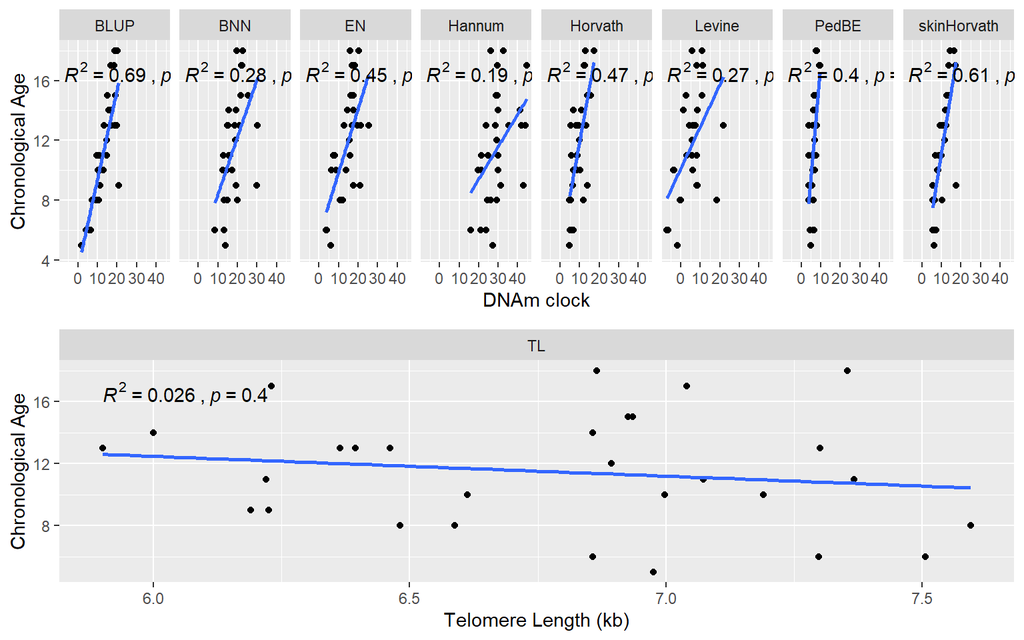

```r
plotCorClocks(age.gse)
```

# 5 Gestational DNAm age estimation

## 5.1 Model predicion

Let us start by reproducing the example provided in Knight et al. (2016) as a test data set (file ‘TestDataset.csv’). It consists on 3 individuals whose methylation data are available as supplementary data of their paper. The data is also available at `methylclock` package as a data frame.

```r
TestDataset[1:5,]
```

```
       CpGName    Sample1    Sample2    Sample3
  1 cg00000292 0.72546496 0.72350947 0.69023377
  2 cg00002426 0.85091763 0.80077888 0.80385777
  3 cg00003994 0.05125853 0.05943935 0.05559333
  4 cg00005847 0.08775420 0.11722333 0.10845113
  5 cg00006414 0.03982478 0.06146891 0.03491992
```

```r
ga.test <- DNAmGA(TestDataset)
ga.test
```

```
  # A tibble: 3 x 6
    id      Knight Bohlin Mayne EPIC  Lee
    <chr>    <dbl>  <dbl> <dbl> <lgl> <lgl>
  1 Sample1   38.2     NA  35.8 NA    NA
  2 Sample2   38.8     NA  36.5 NA    NA
  3 Sample3   40.0     NA  36.6 NA    NA
```

like in DNAmAge we can use the parameter `min.perc` to set the minimum missing percentage.

The results are the same as those described in the additional file 7 of Knight et al. (2016) (link [here](https://static-content.springer.com/esm/art%3A10.1186%2Fs13059-016-1068-z/MediaObjects/13059_2016_1068_MOESM7_ESM.docx))

Let us continue by illustrating how to compute GA of real examples. The PROGRESS cohort data is available in the additional file 8 of Knight et al. (2016). It is available at `methylclock` as a `tibble`:

```r
progress_data
```

```
  # A tibble: 148 x 151
     CpGmarker  `784` `1052` `1048` `1017` `956` `1038` `989` `946` `941` `1024`
     <chr>      <dbl>  <dbl>  <dbl>  <dbl> <dbl>  <dbl> <dbl> <dbl> <dbl>  <dbl>
   1 cg00022866 0.289  0.372  0.347  0.351 0.313  0.300 0.298 0.294 0.322  0.313
   2 cg00466249 0.658  0.724  0.700  0.717 0.695  0.665 0.710 0.686 0.692  0.704
   3 cg00546897 0.682  0.711  0.684  0.717 0.627  0.605 0.684 0.716 0.684  0.666
   4 cg00575744 0.312  0.381  0.300  0.331 0.294  0.348 0.284 0.305 0.319  0.325
   5 cg00689340 0.566  0.576  0.556  0.571 0.521  0.569 0.599 0.575 0.532  0.564
   6 cg01056568 0.558  0.620  0.529  0.600 0.577  0.574 0.590 0.576 0.548  0.555
   7 cg01184449 0.712  0.718  0.667  0.744 0.668  0.676 0.710 0.744 0.685  0.717
   8 cg01348086 0.195  0.186  0.180  0.194 0.212  0.208 0.183 0.129 0.161  0.144
   9 cg02100629 0.329  0.330  0.340  0.344 0.268  0.280 0.288 0.314 0.283  0.346
  10 cg02813863 0.819  0.858  0.832  0.874 0.861  0.830 0.894 0.873 0.895  0.863
  # ... with 138 more rows, and 140 more variables: `1047` <dbl>, `1035` <dbl>,
  #   `988` <dbl>, `939` <dbl>, `936` <dbl>, `748` <dbl>, `1031` <dbl>,
  #   `903` <dbl>, `864` <dbl>, `874` <dbl>, `898` <dbl>, `1013` <dbl>,
  #   `971` <dbl>, `966` <dbl>, `866` <dbl>, `924` <dbl>, `931` <dbl>,
  #   `1007` <dbl>, `954` <dbl>, `958` <dbl>, `1037` <dbl>, `965` <dbl>,
  #   `1008` <dbl>, `1005` <dbl>, `962` <dbl>, `979` <dbl>, `881` <dbl>,
  #   `876` <dbl>, `764` <dbl>, `743` <dbl>, `987` <dbl>, `930` <dbl>, ...
```

This file also contains different variables that are available in this `tibble`.

```r
progress_vars
```

```
  # A tibble: 150 x 3
     id    birthweight   EGA
     <chr>       <dbl> <dbl>
   1 784          2.62  38
   2 1052         2.59  38.3
   3 1048         3.20  38
   4 1017         3.28  38.6
   5 956          2.79  37.1
   6 1038         2.89  38.1
   7 989          2.47  38
   8 946          2.42  37.7
   9 941          2.96  36.7
  10 1024         2.61  38.6
  # ... with 140 more rows
```

The Clinical Variables including clinical assesment of gestational age (EGA) are available at this `tibble`.

```r
ga.progress <- DNAmGA(progress_data)
ga.progress
```

```
  # A tibble: 150 x 6
     id    Knight Bohlin Mayne EPIC  Lee
     <chr>  <dbl>  <dbl> <lgl> <lgl> <lgl>
   1 784     38.8     NA NA    NA    NA
   2 1052    37.2     NA NA    NA    NA
   3 1048    40.3     NA NA    NA    NA
   4 1017    39.2     NA NA    NA    NA
   5 956     38.9     NA NA    NA    NA
   6 1038    39.2     NA NA    NA    NA
   7 989     37.2     NA NA    NA    NA
   8 946     35.4     NA NA    NA    NA
   9 941     33.5     NA NA    NA    NA
  10 1024    37.4     NA NA    NA    NA
  # ... with 140 more rows
```

We can compare these results with the clinical GA available in the variable EGA

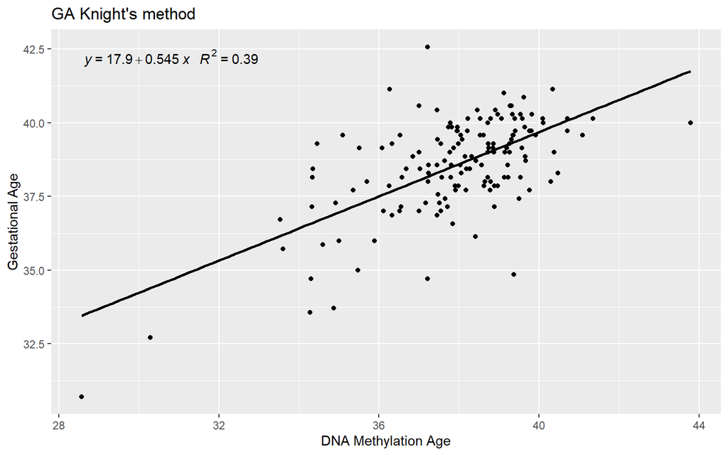

```r
plotDNAmAge(ga.progress$Knight, progress_vars$EGA,
            tit="GA Knight's method",
            clock="GA")
```

Figure 3b (only for PROGRESS dataset) in Knight et al. (2016) representing the correlation between GA acceleration and birthweight can be reproduced by

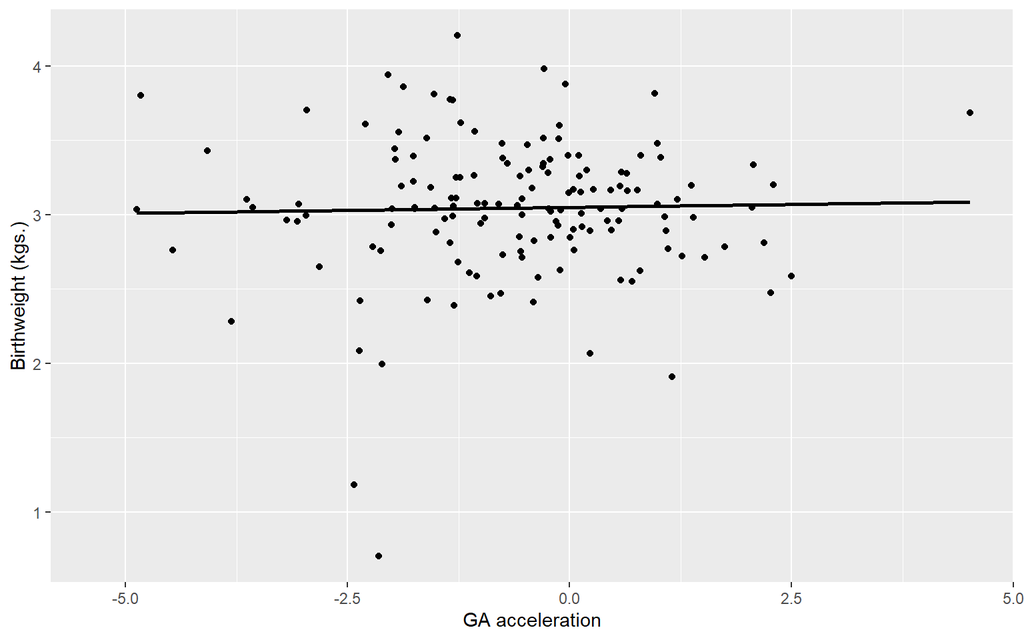

```r
library(ggplot2)
progress_vars$acc <- ga.progress$Knight - progress_vars$EGA
p <- ggplot(data=progress_vars, aes(x = acc, y = birthweight)) +
  geom_point() +
  geom_smooth(method = "lm", se=FALSE, color="black") +
  xlab("GA acceleration") +
  ylab("Birthweight (kgs.)")
p
```

Finally, we can also estimate the “accelerated gestational age” using two of the the three different estimates previously described (`accAge`, `accAge2`) by provinding information of gestational age through `age` argument. Notice that in that case `accAge3` cannot be estimates since we do not have all the CpGs required by the default reference panel to estimate cell counts for gestational age which is “andrews and bakulski cord blood”.

```r
accga.progress <- DNAmGA(progress_data,
                         age = progress_vars$EGA,
                         cell.count=FALSE)
accga.progress
```

```
  # A tibble: 150 x 9
     id    Knight ageAcc.Knight ageAcc2.Knight Bohlin Mayne EPIC  Lee     age
     <chr>  <dbl>         <dbl>          <dbl>  <dbl> <lgl> <lgl> <lgl> <dbl>
   1 784     38.8         0.792          1.27      NA NA    NA    NA     38
   2 1052    37.2        -1.05          -0.488     NA NA    NA    NA     38.3
   3 1048    40.3         2.29           2.77      NA NA    NA    NA     38
   4 1017    39.2         0.643          1.28      NA NA    NA    NA     38.6
   5 956     38.9         1.75           1.99      NA NA    NA    NA     37.1
   6 1038    39.2         1.09           1.61      NA NA    NA    NA     38.1
   7 989     37.2        -0.774         -0.292     NA NA    NA    NA     38
   8 946     35.4        -2.36          -1.96      NA NA    NA    NA     37.7
   9 941     33.5        -3.18          -3.06      NA NA    NA    NA     36.7
  10 1024    37.4        -1.12          -0.486     NA NA    NA    NA     38.6
  # ... with 140 more rows
```

One can also check which clocks can be estimated given the CpGs available in the methylation data by

```r
checkClocksGA(progress_data)
```

```
  There are some clocks that cannot be computed since your data do not contain the required CpGs.
          These are the total number of missing CpGs for each clock :

     clock Cpgs_in_clock missing_CpGs percentage
  1 Knight           148            0        0.0
  2 Bohlin            96           94       97.9
  3  Mayne            62           61       98.4
  4    Lee          1125         1125      100.0
  5   EPIC           176          176      100.0
```

# 6 Correlation among DNAm clocks

We can compute the correlation among biological clocks using the function `plotCorClocks` that requires the package `ggplot2` and `ggpubr` to be installed in your computer.

We can obtain, for instance, the correlation among the clocks estimated for the healthy individuals study previosuly analyze (GEO accession number GSE58045) by simply executing:

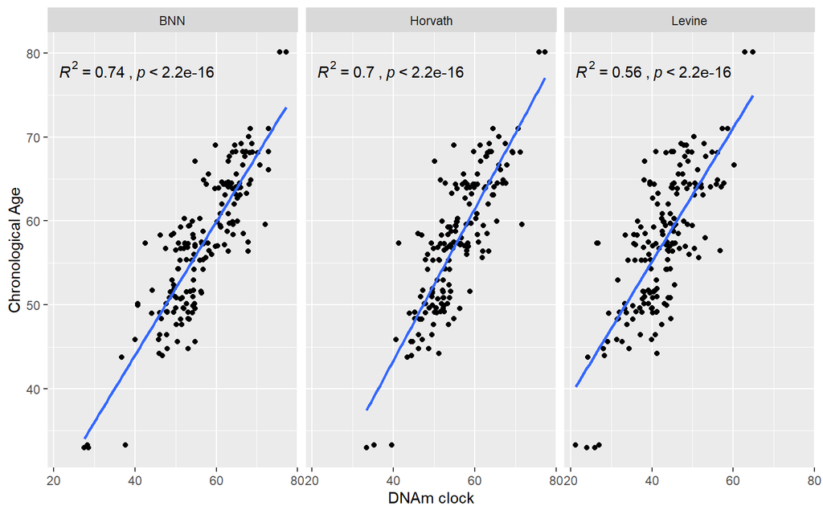

[output not shown]

[output cut: 94 more lines]

```r
plotCorClocks(age.gse58045)
```

# References

Alfonso, Gerardo, and Juan R Gonzalez. 2020. “Bayesian Neural Networks Improve Methylation Age Estimates.” *bioRxiv*.

Bakulski, Kelly M, Jason I Feinberg, Shan V Andrews, Jack Yang, Shannon Brown, Stephanie L. McKenney, Frank Witter, Jeremy Walston, Andrew P Feinberg, and M Daniele Fallin. 2016. “DNA Methylation of Cord Blood Cell Types: Applications for Mixed Cell Birth Studies.” *Epigenetics* 11 (5): 354–62.

Bohlin, Jon, Siri Eldevik Håberg, Per Magnus, Sarah E Reese, Håkon K Gjessing, Maria Christine Magnus, Christine Louise Parr, CM Page, Stephanie J London, and Wenche Nystad. 2016. “Prediction of Gestational Age Based on Genome-Wide Differentially Methylated Regions.” *Genome Biology* 17 (1): 207.

Chen, Wei, Ting Wang, Maria Pino-Yanes, Erick Forno, Liming Liang, Qi Yan, Donglei Hu, et al. 2017. “An Epigenome-Wide Association Study of Total Serum IgE in Hispanic Children.” *Journal of Allergy and Clinical Immunology* 140 (2): 571–77.

Goede, Olivia M de, Hamid R Razzaghian, E Magda Price, Meaghan J Jones, Michael S Kobor, Wendy P Robinson, and Pascal M Lavoie. 2015. “Nucleated Red Blood Cells Impact DNA Methylation and Expression Analyses of Cord Blood Hematopoietic Cells.” *Clinical Epigenetics* 7 (1): 95.

Guintivano, Jerry, Martin J Aryee, and Zachary A Kaminsky. 2013. “A Cell Epigenotype Specific Model for the Correction of Brain Cellular Heterogeneity Bias and Its Application to Age, Brain Region and Major Depression.” *Epigenetics* 8 (3): 290–302.

Haftorn, Kristine L, Yunsung Lee, William RP Denault, Christian M Page, Haakon E Nustad, Robert Lyle, Håkon K Gjessing, et al. 2021. “An EPIC Predictor of Gestational Age and Its Application to Newborns Conceived by Assisted Reproductive Technologies.” *Clinical Epigenetics* 13 (1): 1–13.

Hannum, Gregory, Justin Guinney, Ling Zhao, Li Zhang, Guy Hughes, SriniVas Sadda, Brandy Klotzle, et al. 2013. “Genome-Wide Methylation Profiles Reveal Quantitative Views of Human Aging Rates.” *Molecular Cell* 49 (2): 359–67.

Horvath, Steve. 2013. “DNA Methylation Age of Human Tissues and Cell Types.” *Genome Biology* 14 (10): 3156.

Horvath, Steve, Junko Oshima, George M Martin, Ake T Lu, Austin Quach, Howard Cohen, Sarah Felton, et al. 2018. “Epigenetic Clock for Skin and Blood Cells Applied to Hutchinson Gilford Progeria Syndrome and Ex Vivo Studies.” *Aging (Albany NY)* 10 (7): 1758.

Knight, Anna K, Jeffrey M Craig, Christiane Theda, Marie Bækvad-Hansen, Jonas Bybjerg-Grauholm, Christine S Hansen, Mads V Hollegaard, et al. 2016. “An Epigenetic Clock for Gestational Age at Birth Based on Blood Methylation Data.” *Genome Biology* 17 (1): 206.

Lee, Yunsung, Sanaa Choufani, Rosanna Weksberg, Samantha L Wilson, Victor Yuan, Amber Burt, Carmen Marsit, et al. 2019. “Placental Epigenetic Clocks: Estimating Gestational Age Using Placental DNA Methylation Levels.” *Aging (Albany NY)* 11 (12): 4238.

Levine, Morgan E, Ake T Lu, Austin Quach, Brian H Chen, Themistocles L Assimes, Stefania Bandinelli, Lifang Hou, et al. 2018. “An Epigenetic Biomarker of Aging for Lifespan and Healthspan.” *Aging (Albany NY)* 10 (4): 573.

Lu, Ake T, Anne Seeboth, Pei-Chien Tsai, Dianjianyi Sun, Austin Quach, Alex P Reiner, Charles Kooperberg, et al. 2019. “DNA Methylation-Based Estimator of Telomere Length.” *Aging (Albany NY)* 11 (16): 5895.

Mayne, Benjamin T, Shalem Y Leemaqz, Alicia K Smith, James Breen, Claire T Roberts, and Tina Bianco-Miotto. 2017. “Accelerated Placental Aging in Early Onset Preeclampsia Pregnancies Identified by DNA Methylation.” *Epigenomics* 9 (3): 279–89.

McEwen, Lisa M, Kieran J O?Donnell, Megan G McGill, Rachel D Edgar, Meaghan J Jones, Julia L MacIsaac, David Tse Shen Lin, et al. 2019. “The PedBE Clock Accurately Estimates DNA Methylation Age in Pediatric Buccal Cells.” *Proceedings of the National Academy of Sciences*, 201820843.

Min, JL, G Hemani, G Davey Smith, C Relton, M Suderman, and John Hancock. 2018. “Meffil: Efficient Normalization and Analysis of Very Large DNA Methylation Datasets.” *Bioinformatics*.

Reinius, Lovisa E, Nathalie Acevedo, Maaike Joerink, Göran Pershagen, Sven-Erik Dahlén, Dario Greco, Cilla Söderhäll, Annika Scheynius, and Juha Kere. 2012. “Differential DNA Methylation in Purified Human Blood Cells: Implications for Cell Lineage and Studies on Disease Susceptibility.” *PloS One* 7 (7): e41361.

Slieker, Roderick C, Steffan D Bos, Jelle J Goeman, Judith VMG Bovée, Rudolf P Talens, Ruud van der Breggen, H Eka D Suchiman, et al. 2013. “Identification and Systematic Annotation of Tissue-Specific Differentially Methylated Regions Using the Illumina 450k Array.” *Epigenetics & Chromatin* 6 (1): 26.

Teschendorff, Andrew E, Francesco Marabita, Matthias Lechner, Thomas Bartlett, Jesper Tegner, David Gomez-Cabrero, and Stephan Beck. 2012. “A Beta-Mixture Quantile Normalization Method for Correcting Probe Design Bias in Illumina Infinium 450 k DNA Methylation Data.” *Bioinformatics* 29 (2): 189–96.

Wang, Ting, Weihua Guan, Jerome Lin, Nadia Boutaoui, Glorisa Canino, Jianhua Luo, Juan Carlos Celedón, and Wei Chen. 2015. “A Systematic Study of Normalization Methods for Infinium 450k Methylation Data Using Whole-Genome Bisulfite Sequencing Data.” *Epigenetics* 10 (7): 662–69.

Wu, Xiaohui, Weidan Chen, Fangqin Lin, Qingsheng Huang, Jiayong Zhong, Huan Gao, Yanyan Song, and Huiying Liang. 2019. “DNA Methylation Profile Is a Quantitative Measure of Biological Aging in Children.” *Aging (Albany NY)* 11 (22): 10031.

Yuan, Victor. 2022. *Placental DNA Methylation Analysis Tools*. https://doi.org/10.18129/B9.bioc.planet.

Yuan, Victor, Desmond Hui, Maria S. Penaherrera, Alexander G. Beristain, and Wendy P. Robinson. 2021. “Cell-Specific Characterization of the Placental Methylome.” *BMC Genomics*. https://doi.org/10.1186/s12864-020-07186-6.

Zhang, Qian, Costanza L Vallerga, Rosie M Walker, Tian Lin, Anjali K Henders, Grant W Montgomery, Ji He, et al. 2019. “Improved Precision of Epigenetic Clock Estimates Across Tissues and Its Implication for Biological Ageing.” *Genome Medicine* 11 (1): 1–11.